# Vaccine allocation project results

GMB

2022-08-02

# 1 Introduction

This document brings together results from multiple model runs. It is intended to be re-run as the model is updated.

NOTE: The setting for this run is: SLE

**Focus questions:**

- What impact will the existing vaccination plan have on morbidity and mortality?
- What impact can be achieved under different levels of vaccine coverage?
- What are the potential benefits of expanding the immunisation schedule to include children?

**Overarching assumptions**

Unless otherwise specified, key model parameters in this run are:

| Variable | Value | Source |
| --- | --- | --- |
| Circulating strain | omicron |  |
| Length of model run | 52 |  |
| Current vaccine coverage | dose one: 32%; dose two: 23% | John Hopkins COVID-19 vaccination data |
| Current vaccine coverage target | 51.6% | Government target in COVAX documentation May 2021 |
| Proportion of population willing to be vaccinated | 88% | Survey estimating vaccine acceptance in January 2021 (Solis et al., 2021) |
| Daily capacity for vaccination (doses) | 11075 | Slightly lower than the pilot vaccination campaign October-November 2021 |
| Anticipated type of future vaccine doses | Johnson & Johnson | The Government of Sierra Leone has demonstrated a strong preference for this vaccine, negotiating with major donors, such as the Government of Italy, to change their donations of double-dose vaccines … |
| Interval between doses | 90 days |  |
| Waning of VE against acquisition | TRUE |  |
| Waning of VE against severe disease | FALSE |  |
| Waning of infection-derived immunity against acquisition | TRUE |  |
| Waning of infection-derived immunity against severe outcomes | Not yet included |  |
| YLL discounting | 0 |  |

**Other assumptions/limitations:**

- Linear roll-out of vaccines (Lowy Institute report and trends in the ACT do not support this)
- Vaccine effectiveness estimates last updated on the 14th of April 2022 from WHO live systematic review (https://view-hub.org/covid-19/effectiveness-studies)

**Next steps for noting:**

- update of infection- and vaccine-derived immunity
- sensitivity analysis
  - turning on/off waning of vaccine-derived immunity
  - simulating outbreaks of different strains
  - experimenting with different age-prioritisation strategies
  - other?

# 2 Impact of current program targets

Roll out of current program target (51.6% coverage) during or prior to an outbreak:

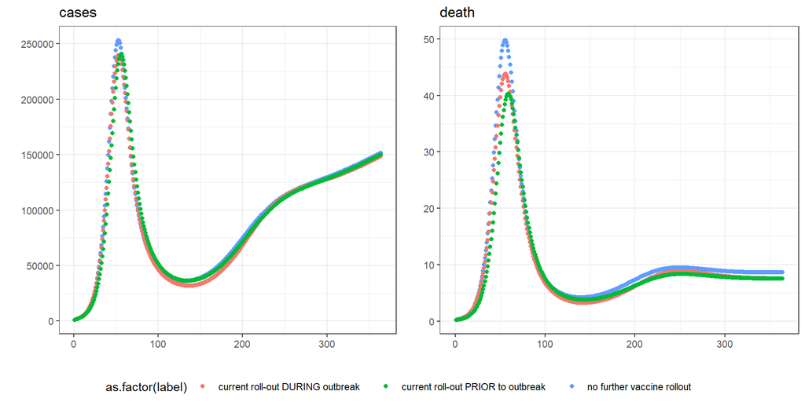

Absolute difference in outcomes (compared to no further vaccine roll-out)

| scenario | death | hosp | severe_disease | YLL | cases |
| --- | --- | --- | --- | --- | --- |
| current roll-out DURING outbreak | 428 | 15,752 | 5,195 | 4,516 | 1,148,216 |
| current roll-out PRIOR to outbreak | 546 | 21,459 | 7,005 | 5,961 | 604,611 |

Relative difference in outcomes

| scenario | death | hosp | severe_disease | YLL | cases |
| --- | --- | --- | --- | --- | --- |
| current roll-out DURING outbreak | 11.05 | 6.82 | 10.35 | 9.13 | 3.35 |
| current roll-out PRIOR to outbreak | 14.10 | 9.29 | 13.96 | 12.04 | 1.76 |

# 3 Varying levels of coverage

## 3.1 Using current age-specific eligiblity

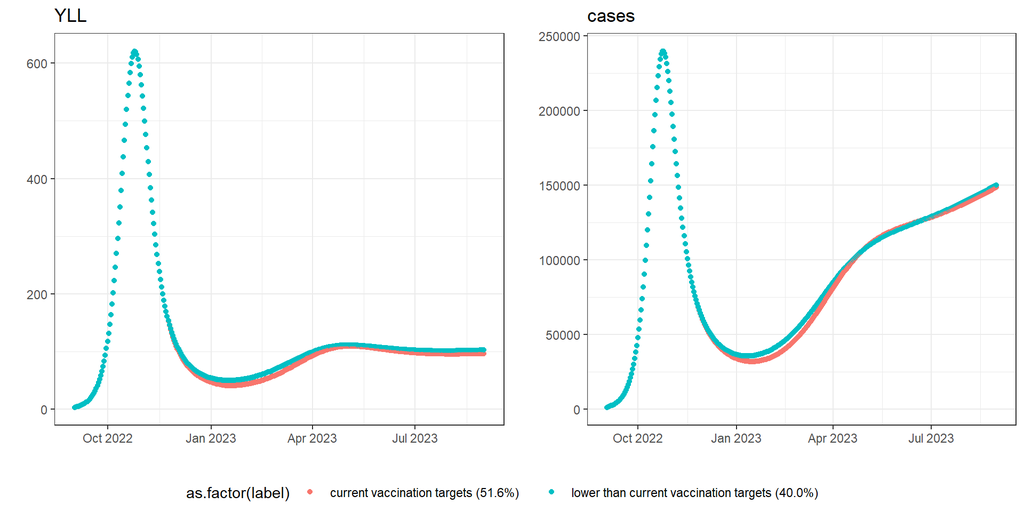

Absolute difference in outcomes (compared to current vaccine targets)

| scenario | macro_age_group | death | hosp | severe_disease | YLL | cases |
| --- | --- | --- | --- | --- | --- | --- |
| lower than current vaccination targets (40.0%) | adults | -153 | -5,514 | -1,876 | -1,601 | -427,899 |
| lower than current vaccination targets (40.0%) | children | -1 | -317 | -5 | -34 | -156,014 |
| lower than current vaccination targets (40.0%) | net | -154 | -5,831 | -1,881 | -1,635 | -583,913 |

Relative difference in outcomes (%)

| scenario | macro_age_group | death | hosp | severe_disease | YLL | cases |
| --- | --- | --- | --- | --- | --- | --- |
| lower than current vaccination targets (40.0%) | adults | -4.64 | -4.18 | -4.29 | -4.42 | -2.22 |
| lower than current vaccination targets (40.0%) | children | -0.38 | -0.38 | -0.37 | -0.38 | -1.13 |
| lower than current vaccination targets (40.0%) | net | -4.46 | -2.71 | -4.18 | -3.64 | -1.76 |

## 3.2 Expanding eligibility to children (DURING an outbreak)

### 3.2.1 Run current vaccine campaign, then expand to children

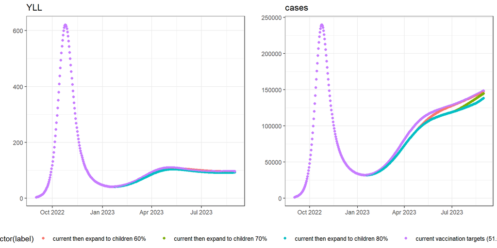

Absolute difference in outcomes (compared to current vaccine targets)

| scenario | macro_age_group | death | hosp | severe_disease | YLL | cases |
| --- | --- | --- | --- | --- | --- | --- |
| current then expand to children 60% | adults | 18 | 432 | 169 | 156 | 184,635 |
| current then expand to children 60% | children | 5 | 3,294 | 54 | 317 | 627,148 |
| current then expand to children 60% | net | 24 | 3,727 | 223 | 474 | 811,784 |
| current then expand to children 70% | adults | 37 | 865 | 341 | 316 | 351,047 |
| current then expand to children 70% | children | 9 | 5,243 | 85 | 506 | 1,194,723 |
| current then expand to children 70% | net | 46 | 6,108 | 426 | 822 | 1,545,770 |
| current then expand to children 80% | adults | 43 | 1,009 | 396 | 366 | 395,548 |
| current then expand to children 80% | children | 10 | 5,841 | 95 | 564 | 1,375,137 |
| current then expand to children 80% | net | 52 | 6,850 | 491 | 930 | 1,770,685 |

Relative difference in outcomes (%)

| scenario | macro_age_group | death | hosp | severe_disease | YLL | cases |
| --- | --- | --- | --- | --- | --- | --- |
| current then expand to children 60% | adults | 0.55 | 0.33 | 0.39 | 0.43 | 0.96 |
| current then expand to children 60% | children | 3.78 | 3.95 | 4.44 | 3.62 | 4.54 |
| current then expand to children 60% | net | 0.69 | 1.73 | 0.50 | 1.05 | 2.45 |
| current then expand to children 70% | adults | 1.12 | 0.66 | 0.78 | 0.87 | 1.82 |
| current then expand to children 70% | children | 6.02 | 6.29 | 7.04 | 5.78 | 8.65 |
| current then expand to children 70% | net | 1.33 | 2.84 | 0.95 | 1.83 | 4.67 |
| current then expand to children 80% | adults | 1.29 | 0.77 | 0.90 | 1.01 | 2.05 |
| current then expand to children 80% | children | 6.70 | 7.00 | 7.84 | 6.44 | 9.95 |
| current then expand to children 80% | net | 1.52 | 3.18 | 1.09 | 2.07 | 5.34 |

### 3.2.2 Expand to children now

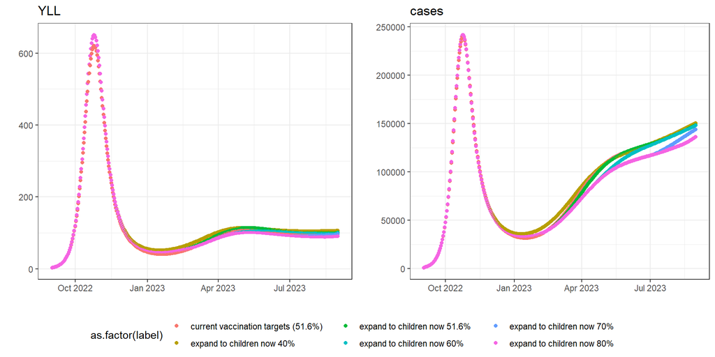

Absolute difference in outcomes (compared to current vaccine targets)

| scenario | macro_age_group | death | hosp | severe_disease | YLL | cases |
| --- | --- | --- | --- | --- | --- | --- |
| expand to children now 40% | adults | -322 | -11,561 | -3,946 | -3,377 | -616,302 |
| expand to children now 40% | children | 3 | 1,964 | 33 | 183 | -57,756 |
| expand to children now 40% | net | -319 | -9,596 | -3,912 | -3,193 | -674,058 |
| expand to children now 51.6% | adults | -227 | -8,226 | -2,804 | -2,398 | -236,997 |
| expand to children now 51.6% | children | 7 | 4,367 | 72 | 416 | 314,530 |
| expand to children now 51.6% | net | -220 | -3,858 | -2,731 | -1,981 | 77,533 |
| expand to children now 60% | adults | -165 | -6,136 | -2,078 | -1,770 | 86,504 |
| expand to children now 60% | children | 10 | 5,857 | 96 | 561 | 668,246 |
| expand to children now 60% | net | -155 | -279 | -1,982 | -1,209 | 754,751 |
| expand to children now 70% | adults | -101 | -4,123 | -1,365 | -1,146 | 506,674 |
| expand to children now 70% | children | 12 | 7,278 | 119 | 701 | 1,129,546 |
| expand to children now 70% | net | -89 | 3,155 | -1,246 | -445 | 1,636,220 |
| expand to children now 80% | adults | -84 | -3,539 | -1,160 | -969 | 627,586 |
| expand to children now 80% | children | 13 | 7,707 | 126 | 744 | 1,268,830 |
| expand to children now 80% | net | -71 | 4,168 | -1,035 | -226 | 1,896,417 |

Relative difference in outcomes (%)

| scenario | macro_age_group | death | hosp | severe_disease | YLL | cases |
| --- | --- | --- | --- | --- | --- | --- |
| expand to children now 40% | adults | -9.75 | -8.76 | -9.01 | -9.32 | -3.19 |
| expand to children now 40% | children | 2.21 | 2.36 | 2.75 | 2.09 | -0.42 |
| expand to children now 40% | net | -9.25 | -4.46 | -8.70 | -7.10 | -2.03 |
| expand to children now 51.6% | adults | -6.87 | -6.24 | -6.40 | -6.62 | -1.23 |
| expand to children now 51.6% | children | 4.98 | 5.24 | 5.95 | 4.75 | 2.28 |
| expand to children now 51.6% | net | -6.38 | -1.79 | -6.07 | -4.41 | 0.23 |
| expand to children now 60% | adults | -4.99 | -4.65 | -4.75 | -4.89 | 0.45 |
| expand to children now 60% | children | 6.70 | 7.02 | 7.94 | 6.41 | 4.84 |
| expand to children now 60% | net | -4.50 | -0.13 | -4.40 | -2.69 | 2.28 |
| expand to children now 70% | adults | -3.07 | -3.13 | -3.12 | -3.17 | 2.62 |
| expand to children now 70% | children | 8.34 | 8.73 | 9.80 | 8.00 | 8.18 |
| expand to children now 70% | net | -2.59 | 1.47 | -2.77 | -0.99 | 4.94 |
| expand to children now 80% | adults | -2.53 | -2.68 | -2.65 | -2.68 | 3.25 |
| expand to children now 80% | children | 8.84 | 9.24 | 10.36 | 8.49 | 9.18 |
| expand to children now 80% | net | -2.06 | 1.94 | -2.30 | -0.50 | 5.72 |

## 3.3 Expanding eligibility to children (PRIOR TO an outbreak)

Note: If waning immunity against severe outcomes ON, this looks like a bad idea.

### 3.3.1 Run current vaccine campaign, then expand to children

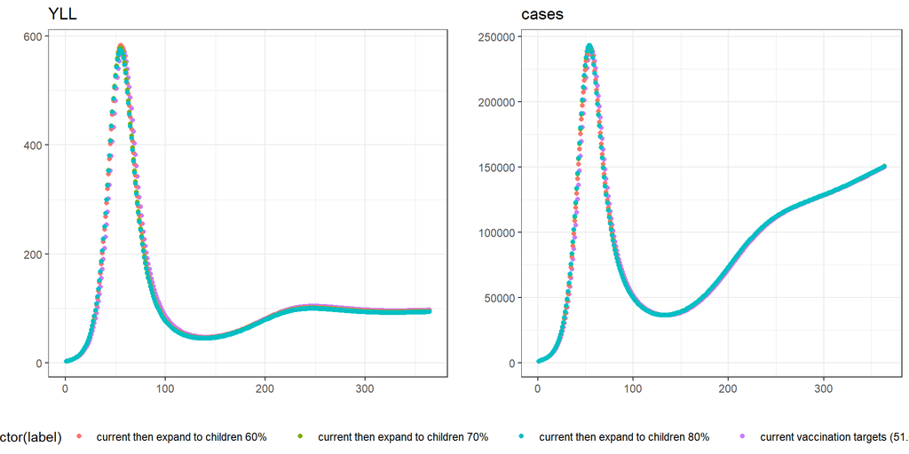

Absolute difference in outcomes (compared to current vaccine targets)

| scenario | macro_age_group | death | hosp | severe_disease | YLL | cases |
| --- | --- | --- | --- | --- | --- | --- |
| current then expand to children 60% | adults | -26 | -835 | -295 | -259 | -229,265 |
| current then expand to children 60% | children | 11 | 6,949 | 115 | 661 | 43,158 |
| current then expand to children 60% | net | -14 | 6,114 | -179 | 402 | -186,107 |
| current then expand to children 70% | adults | -31 | -1,015 | -358 | -314 | -271,616 |
| current then expand to children 70% | children | 20 | 12,598 | 209 | 1,201 | 49,204 |
| current then expand to children 70% | net | -10 | 11,583 | -149 | 887 | -222,412 |
| current then expand to children 80% | adults | -32 | -1,046 | -368 | -323 | -278,166 |
| current then expand to children 80% | children | 26 | 15,712 | 260 | 1,498 | 52,521 |
| current then expand to children 80% | net | -6 | 14,666 | -108 | 1,175 | -225,646 |

Relative difference in outcomes (%)

| scenario | macro_age_group | death | hosp | severe_disease | YLL | cases |
| --- | --- | --- | --- | --- | --- | --- |
| current then expand to children 60% | adults | -0.81 | -0.66 | -0.70 | -0.75 | -1.16 |
| current then expand to children 60% | children | 7.91 | 8.32 | 9.48 | 7.54 | 0.31 |
| current then expand to children 60% | net | -0.43 | 2.92 | -0.42 | 0.92 | -0.55 |
| current then expand to children 70% | adults | -0.97 | -0.81 | -0.85 | -0.90 | -1.37 |
| current then expand to children 70% | children | 14.35 | 15.09 | 17.17 | 13.69 | 0.35 |
| current then expand to children 70% | net | -0.31 | 5.53 | -0.34 | 2.04 | -0.66 |
| current then expand to children 80% | adults | -1.00 | -0.83 | -0.88 | -0.93 | -1.41 |
| current then expand to children 80% | children | 17.90 | 18.82 | 21.40 | 17.08 | 0.38 |
| current then expand to children 80% | net | -0.19 | 7.00 | -0.25 | 2.70 | -0.67 |

### 3.3.2 Expand to children now

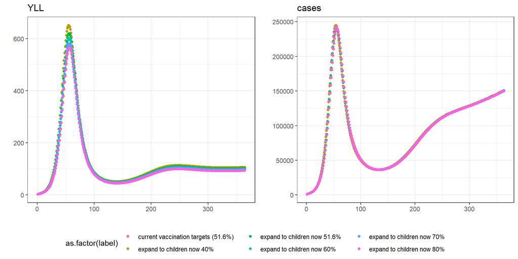

Absolute difference in outcomes (compared to current vaccine targets)

| scenario | macro_age_group | death | hosp | severe_disease | YLL | cases |
| --- | --- | --- | --- | --- | --- | --- |
| expand to children now 40% | adults | -434 | -16,749 | -5,594 | -4,716 | -261,389 |
| expand to children now 40% | children | 4 | 2,614 | 44 | 247 | -47,833 |
| expand to children now 40% | net | -430 | -14,135 | -5,550 | -4,469 | -309,222 |
| expand to children now 51.6% | adults | -293 | -11,309 | -3,778 | -3,187 | -188,466 |
| expand to children now 51.6% | children | 11 | 6,977 | 116 | 665 | 23,826 |
| expand to children now 51.6% | net | -282 | -4,332 | -3,663 | -2,523 | -164,640 |
| expand to children now 60% | adults | -196 | -7,518 | -2,515 | -2,125 | -170,941 |
| expand to children now 60% | children | 16 | 10,079 | 167 | 961 | 40,317 |
| expand to children now 60% | net | -180 | 2,561 | -2,349 | -1,163 | -130,624 |
| expand to children now 70% | adults | -81 | -3,047 | -1,026 | -872 | -160,432 |
| expand to children now 70% | children | 22 | 13,756 | 227 | 1,313 | 50,161 |
| expand to children now 70% | net | -59 | 10,709 | -799 | 441 | -110,271 |
| expand to children now 80% | adults | -18 | -602 | -212 | -187 | -156,196 |
| expand to children now 80% | children | 26 | 15,768 | 261 | 1,505 | 54,263 |
| expand to children now 80% | net | 7 | 15,165 | 48 | 1,318 | -101,933 |

Relative difference in outcomes (%)

| scenario | macro_age_group | death | hosp | severe_disease | YLL | cases |
| --- | --- | --- | --- | --- | --- | --- |
| expand to children now 40% | adults | -13.64 | -13.28 | -13.33 | -13.57 | -1.32 |
| expand to children now 40% | children | 2.96 | 3.13 | 3.61 | 2.81 | -0.34 |
| expand to children now 40% | net | -12.93 | -6.74 | -12.85 | -10.27 | -0.92 |
| expand to children now 51.6% | adults | -9.22 | -8.97 | -9.00 | -9.17 | -0.95 |
| expand to children now 51.6% | children | 7.94 | 8.36 | 9.51 | 7.58 | 0.17 |
| expand to children now 51.6% | net | -8.48 | -2.07 | -8.48 | -5.80 | -0.49 |
| expand to children now 60% | adults | -6.16 | -5.96 | -5.99 | -6.11 | -0.87 |
| expand to children now 60% | children | 11.48 | 12.08 | 13.72 | 10.96 | 0.29 |
| expand to children now 60% | net | -5.40 | 1.22 | -5.44 | -2.67 | -0.39 |
| expand to children now 70% | adults | -2.55 | -2.42 | -2.45 | -2.51 | -0.81 |
| expand to children now 70% | children | 15.67 | 16.48 | 18.72 | 14.96 | 0.36 |
| expand to children now 70% | net | -1.77 | 5.11 | -1.85 | 1.01 | -0.33 |
| expand to children now 80% | adults | -0.58 | -0.48 | -0.51 | -0.54 | -0.79 |
| expand to children now 80% | children | 17.97 | 18.89 | 21.45 | 17.16 | 0.39 |
| expand to children now 80% | net | 0.22 | 7.24 | 0.11 | 3.03 | -0.30 |

# 4 Varying speed of vaccine roll-out

This section models varying speeds of vaccine roll-out *DURING* an outbreak.

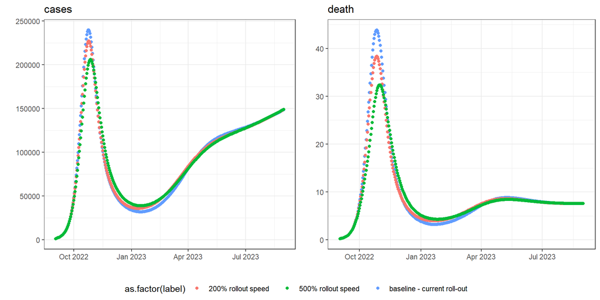

Absolute difference in outcomes (compared to current rollout speed)

| scenario | death | hosp | severe_disease | YLL | cases |
| --- | --- | --- | --- | --- | --- |
| 200% rollout speed | 100 | 3,430 | 1,214 | 1,044 | -118,966 |
| 500% rollout speed | 173 | 7,009 | 2,309 | 1,939 | -97,561 |

Relative difference in outcomes (%)

| scenario | death | hosp | severe_disease | YLL | cases |
| --- | --- | --- | --- | --- | --- |
| 200% rollout speed | 2.89 | 1.59 | 2.70 | 2.32 | -0.36 |
| 500% rollout speed | 5.03 | 3.26 | 5.13 | 4.31 | -0.29 |

# 5 Sensitivity analysis (see FleetDeputy output)

# 6 Appendix - parameter estimates

**Vaccine effectiveness estimates**

**Point estimates by type, dose and outcome**

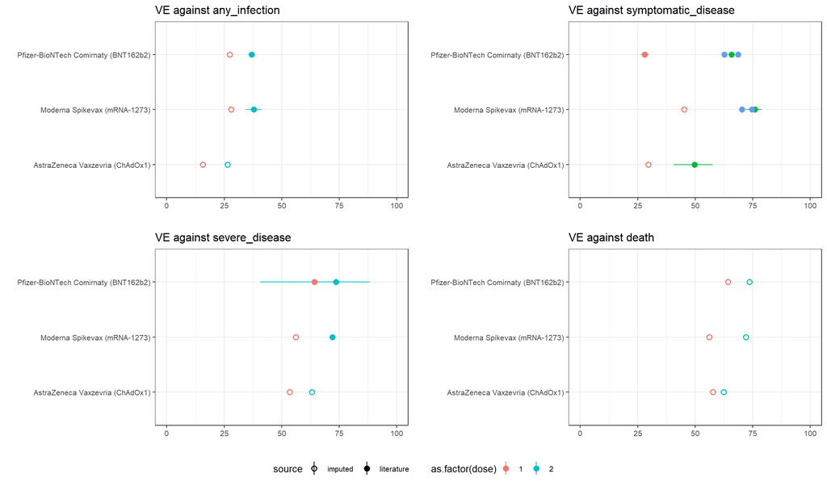

**Duration of protection (shape of waning immunity)**

[output not shown]

**Infection-derived immunity estimate**

Rho severe outcomes: 0.88

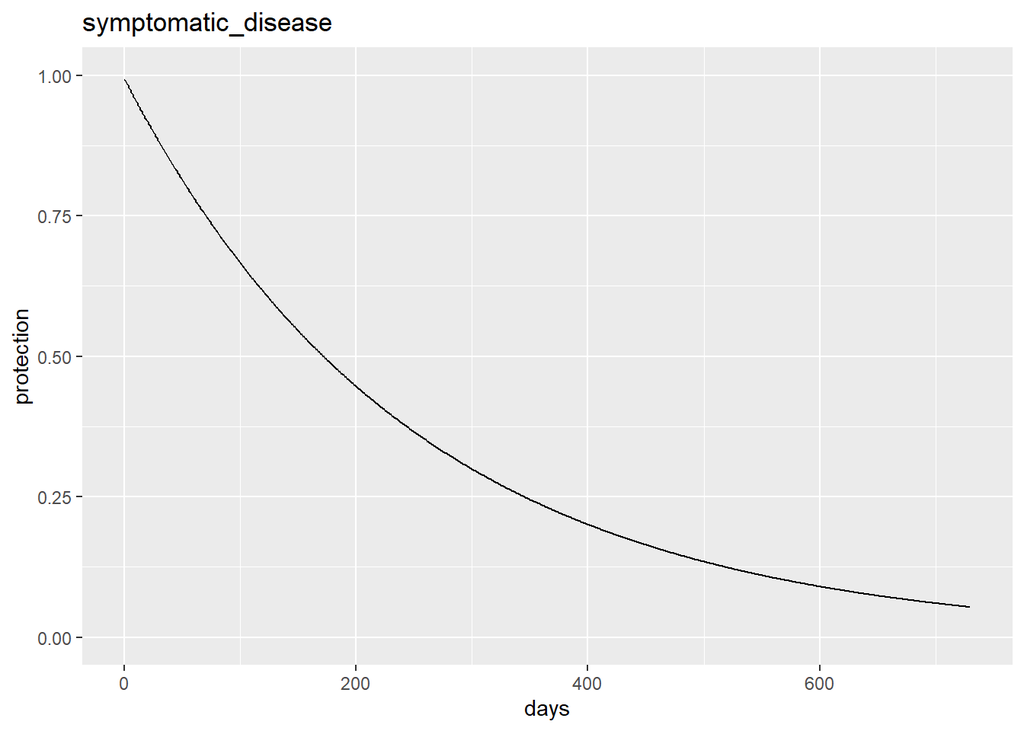

**Seroprevalence**

| age_group | seroprev |
| --- | --- |
| 0 to 4 | 7.643630 |
| 5 to 17 | 10.040014 |
| 18 to 29 | 6.607331 |
| 30 to 44 | 9.297261 |
| 45 to 59 | 19.783513 |
| 60 to 69 | 16.186511 |
| 70 to 100 | 16.186511 |

**Other key parameters**

| Variable | Value | Source |
| --- | --- | --- |
| Seed of outbreak (initially infected) | 8306.442 individuals |  |
| Delay from first dose to protection | 21 days |  |
| Delay from second dose to protection | 14 days |  |